# Census Data in R

Focused on the census data from `tidycensus`. API key required via census.gov.

```r
library(tidyverse)
library(tidycensus)
library(tigris)
```

# Census data in R with tidycensus

`get_decennial` requires the geography (level of aggregation) and variables parameters.

`get_acs` - American Community Survey data - based on samples, or estimates of the population. Dataframes returned from this function will have estimates and moe (margin of error for 90% CI).

```r
# Obtain and view state populations from the 2010 US Census
state_pop <- get_decennial(geography = "state", variables = "P001001")
state_pop
```

| GEOID | NAME | variable | value |
| --- | --- | --- | --- |
| 01 | Alabama | P001001 | 4779736 |
| 02 | Alaska | P001001 | 710231 |
| 04 | Arizona | P001001 | 6392017 |
| 05 | Arkansas | P001001 | 2915918 |
| 06 | California | P001001 | 37253956 |
| 08 | Colorado | P001001 | 5029196 |
| 09 | Connecticut | P001001 | 3574097 |
| 10 | Delaware | P001001 | 897934 |
| 11 | District of Columbia | P001001 | 601723 |
| 12 | Florida | P001001 | 18801310 |

[output cut: 42 more lines]

```r
# Obtain and view state median household income from the 2012-2016 American Community Survey
state_income <- get_acs(geography = "state", variables = "B19013_001")
state_income
```

| GEOID | NAME | variable | estimate | moe |
| --- | --- | --- | --- | --- |
| 01 | Alabama | B19013_001 | 44758 | 314 |
| 02 | Alaska | B19013_001 | 74444 | 809 |
| 04 | Arizona | B19013_001 | 51340 | 231 |
| 05 | Arkansas | B19013_001 | 42336 | 234 |
| 06 | California | B19013_001 | 63783 | 188 |
| 08 | Colorado | B19013_001 | 62520 | 287 |
| 09 | Connecticut | B19013_001 | 71755 | 473 |
| 10 | Delaware | B19013_001 | 61017 | 723 |
| 11 | District of Columbia | B19013_001 | 72935 | 1164 |
| 12 | Florida | B19013_001 | 48900 | 200 |

[output cut: 42 more lines]

Geography regions - legal entities (e.g. country) - statistical etities (e.g. tract)

`tidycensus` docs include geography available `tidycensus` "returns data in tidy foramt, but can return data in wide format with the `output = "wide"` parameter.

```r
# Get an ACS dataset for Census tracts in Texas by setting the state
# this is the median household income
tx_income <- get_acs(geography = "tract",
                     variables = c(hhincome = "B19013_001"),
                     state = "TX")
# Inspect the dataset
head(tx_income)
```

| GEOID | NAME | variable | estimate | moe |
| --- | --- | --- | --- | --- |
| 48001950100 | Census Tract 9501, Anderson County, Texas | hhincome | 52099 | 4865 |
| 48001950401 | Census Tract 9504.01, Anderson County, Texas | hhincome | 43529 | 27869 |
| 48001950402 | Census Tract 9504.02, Anderson County, Texas | hhincome | 83073 | 38065 |
| 48001950500 | Census Tract 9505, Anderson County, Texas | hhincome | 31000 | 2513 |
| 48001950600 | Census Tract 9506, Anderson County, Texas | hhincome | 50116 | 18631 |
| 48001950700 | Census Tract 9507, Anderson County, Texas | hhincome | 30541 | 4213 |

```r
# Get an ACS dataset for Census tracts in Travis County, TX
travis_income <- get_acs(geography = "tract",
                         variables = "B19013_001",
                         state = "WA",
                         county = "King")
# Inspect the dataset
head(travis_income)
```

| GEOID | NAME | variable | estimate | moe |
| --- | --- | --- | --- | --- |
| 53033000100 | Census Tract 1, King County, Washington | B19013_001 | 48002 | 8140 |
| 53033000200 | Census Tract 2, King County, Washington | B19013_001 | 63727 | 6832 |
| 53033000300 | Census Tract 3, King County, Washington | B19013_001 | 65781 | 17808 |
| 53033000401 | Census Tract 4.01, King County, Washington | B19013_001 | 32196 | 2396 |
| 53033000402 | Census Tract 4.02, King County, Washington | B19013_001 | 61184 | 13257 |
| 53033000500 | Census Tract 5, King County, Washington | B19013_001 | 126544 | 17356 |

```r
# Return county data in wide format
or_wide <- get_acs(geography = "county",
                     state = "OR",
                     variables = c(hhincome = "B19013_001",
                            medage = "B01002_001"),
                     output = "wide")
# Compare output to the tidy format from previous exercises
head(or_wide)
```

| GEOID | NAME | hhincomeE | hhincomeM | medageE | medageM |
| --- | --- | --- | --- | --- | --- |
| 41001 | Baker County, Oregon | 41722 | 1537 | 48.2 | 0.4 |
| 41003 | Benton County, Oregon | 52015 | 2151 | 32.6 | 0.3 |
| 41005 | Clackamas County, Oregon | 68915 | 1137 | 41.4 | 0.2 |
| 41007 | Clatsop County, Oregon | 47492 | 2221 | 43.7 | 0.4 |
| 41009 | Columbia County, Oregon | 55146 | 2256 | 43.3 | 0.4 |
| 41011 | Coos County, Oregon | 39110 | 1423 | 48.2 | 0.3 |

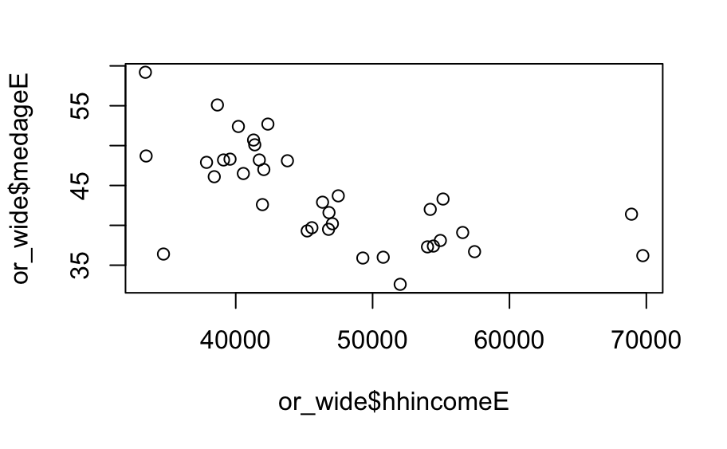

```r
# Create a scatterplot
plot(or_wide$hhincomeE, or_wide$medageE)
```

To find census variables, look at online resources like Census Reporter - https://censusreporter.org/A

`load_variables` helps to find variables. takes year, dataset (`acs5`) and cache boolean, this can then be explored. Returns name, label, and concept fields.

ACS Variable structure B19001_002e B is a base (most data), (C collapsed, DP data profile, or S subject) 19001 is the table ID 002 the variable code within the table E is the estimate (optional in tidycensus, returns both the *E*stimate and *M*argin of error)

```r
# Load variables from the 2012-2016 ACS
v16 <- load_variables(year = 2016,
           dataset = "acs5",
           cache = TRUE)
# Get variables from the ACS Data Profile
v16p <- load_variables(year = 2016,
                       dataset = "acs5/profile",
                       cache = TRUE)
# Set year and dataset to get variables from the 2000 Census SF3
v00 <- load_variables(year = 2000,
                      dataset = "sf3",
                      cache = TRUE)
```

```r
# Filter for table B19001
filter(v16, str_detect(name, "B19001"))
```

| name | label | concept |
| --- | --- | --- |
| B19001_001 | Estimate!!Total | HOUSEHOLD INCOME IN THE PAST 12 MONTHS (IN 2016 INFLATION-ADJUSTED DOLLARS) |
| B19001_002 | Estimate!!Total!!Less than $10,000 | HOUSEHOLD INCOME IN THE PAST 12 MONTHS (IN 2016 INFLATION-ADJUSTED DOLLARS) |
| B19001_003 | Estimate!!Total!!$10,000 to $14,999 | HOUSEHOLD INCOME IN THE PAST 12 MONTHS (IN 2016 INFLATION-ADJUSTED DOLLARS) |
| B19001_004 | Estimate!!Total!!$15,000 to $19,999 | HOUSEHOLD INCOME IN THE PAST 12 MONTHS (IN 2016 INFLATION-ADJUSTED DOLLARS) |
| B19001_005 | Estimate!!Total!!$20,000 to $24,999 | HOUSEHOLD INCOME IN THE PAST 12 MONTHS (IN 2016 INFLATION-ADJUSTED DOLLARS) |
| B19001_006 | Estimate!!Total!!$25,000 to $29,999 | HOUSEHOLD INCOME IN THE PAST 12 MONTHS (IN 2016 INFLATION-ADJUSTED DOLLARS) |
| B19001_007 | Estimate!!Total!!$30,000 to $34,999 | HOUSEHOLD INCOME IN THE PAST 12 MONTHS (IN 2016 INFLATION-ADJUSTED DOLLARS) |
| B19001_008 | Estimate!!Total!!$35,000 to $39,999 | HOUSEHOLD INCOME IN THE PAST 12 MONTHS (IN 2016 INFLATION-ADJUSTED DOLLARS) |
| B19001_009 | Estimate!!Total!!$40,000 to $44,999 | HOUSEHOLD INCOME IN THE PAST 12 MONTHS (IN 2016 INFLATION-ADJUSTED DOLLARS) |
| B19001_010 | Estimate!!Total!!$45,000 to $49,999 | HOUSEHOLD INCOME IN THE PAST 12 MONTHS (IN 2016 INFLATION-ADJUSTED DOLLARS) |

[output cut: 160 more lines]

```r
# Use public transportation to search for related variables
filter(v16p, str_detect(label, fixed("public transportation",
                                ignore_case = TRUE)))
```

| name | label | concept |
| --- | --- | --- |
| DP03_0021 | Estimate!!COMMUTING TO WORK!!Workers 16 years and over!!Public transportation (excluding taxicab) | SELECTED ECONOMIC CHARACTERISTICS |
| DP03_0021P | Percent!!COMMUTING TO WORK!!Workers 16 years and over!!Public transportation (excluding taxicab) | SELECTED ECONOMIC CHARACTERISTICS |

```
The one-year ACS provides data for geographies with populations of 65,000 and greater.
```

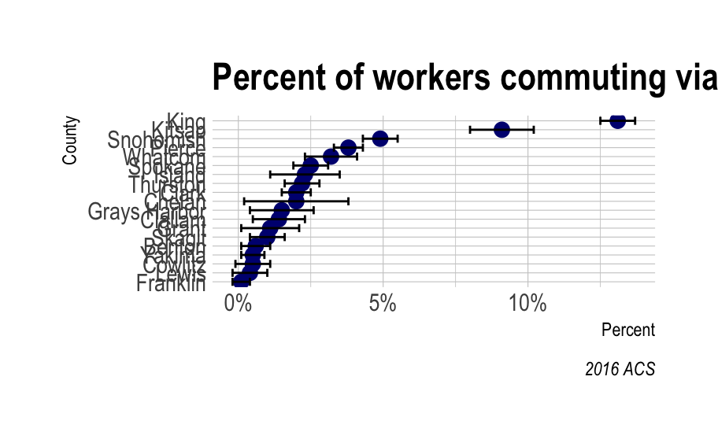

```r
get_acs(geography = "county", state = "WA", year = 2016,
        variables = "DP03_0021P", survey = "acs1") %>%
  mutate(NAME = gsub(" County, Washington", "", NAME)) %>%
  ggplot(aes(estimate, reorder(NAME, estimate))) +
  geom_point(size = 3, color = "navy") +
  geom_errorbarh(aes(xmax = estimate + moe, xmin = estimate - moe)) +
  scale_x_continuous(labels = scales::percent_format(scale = 1, accuracy = 1)) +
  hrbrthemes::theme_ipsum() +
  labs(title = "Percent of workers commuting via public transit",
       caption = "2016 ACS",
       x = "Percent",
       y = "County")
```

# Tables and summary variables in tidycensus

`get_acs` and `get_decennial` have an optional `table` param that allows all the variables to be fetched at once without specifying a variable param.

```r
# Download table "B19001"
wa_income <- get_acs(geography = "county",
                 state = "WA",
                 table = "B19001")
# Check out the first few rows of wa_income
wa_income
```

| GEOID | NAME | variable | estimate | moe |
| --- | --- | --- | --- | --- |
| 53001 | Adams County, Washington | B19001_001 | 5733 | 124 |
| 53001 | Adams County, Washington | B19001_002 | 400 | 100 |
| 53001 | Adams County, Washington | B19001_003 | 252 | 87 |
| 53001 | Adams County, Washington | B19001_004 | 373 | 126 |
| 53001 | Adams County, Washington | B19001_005 | 456 | 133 |
| 53001 | Adams County, Washington | B19001_006 | 396 | 103 |
| 53001 | Adams County, Washington | B19001_007 | 250 | 105 |
| 53001 | Adams County, Washington | B19001_008 | 342 | 82 |
| 53001 | Adams County, Washington | B19001_009 | 273 | 107 |
| 53001 | Adams County, Washington | B19001_010 | 283 | 112 |

[output cut: 653 more lines]

```r
# Assign Census variables vector to race_vars
race_vars <- c(White = "B03002_003", Black = "B03002_004", Native = "B03002_005",
               Asian = "B03002_006", HIPI = "B03002_007", Hispanic = "B03002_012")

# Request a summary variable from the ACS
ca_race <- get_acs(geography = "county",
                   state = "WA",
                   variables = race_vars,
                   summary_var = "B03002_001")
# Calculate a new percentage column and check the result
ca_race_pct <- ca_race %>%
  mutate(pct = 100 * (estimate / summary_est))

ca_race_pct
```

| GEOID | NAME | variable | estimate | moe | summary_est | summary_moe | pct |
| --- | --- | --- | --- | --- | --- | --- | --- |
| 53001 | Adams County, Washington | White | 6813 | 5 | 19100 | NA | 35.67015707 |
| 53001 | Adams County, Washington | Black | 59 | 54 | 19100 | NA | 0.30890052 |
| 53001 | Adams County, Washington | Native | 34 | 37 | 19100 | NA | 0.17801047 |
| 53001 | Adams County, Washington | Asian | 140 | 39 | 19100 | NA | 0.73298429 |
| 53001 | Adams County, Washington | HIPI | 45 | 39 | 19100 | NA | 0.23560209 |
| 53001 | Adams County, Washington | Hispanic | 11820 | NA | 19100 | NA | 61.88481675 |
| 53003 | Asotin County, Washington | White | 20230 | 22 | 22113 | NA | 91.48464704 |
| 53003 | Asotin County, Washington | Black | 56 | 56 | 22113 | NA | 0.25324470 |
| 53003 | Asotin County, Washington | Native | 228 | 102 | 22113 | NA | 1.03106770 |
| 53003 | Asotin County, Washington | Asian | 194 | 40 | 22113 | NA | 0.87731199 |

[output cut: 224 more lines]

```r
# Group the dataset and filter the estimate
ca_largest <- ca_race %>%
  group_by(GEOID) %>%
  filter(estimate == max(estimate))

head(ca_largest)
```

| GEOID | NAME | variable | estimate | moe | summary_est | summary_moe |
| --- | --- | --- | --- | --- | --- | --- |
| 53001 | Adams County, Washington | Hispanic | 11820 | NA | 19100 | NA |
| 53003 | Asotin County, Washington | White | 20230 | 22 | 22113 | NA |
| 53005 | Benton County, Washington | White | 135362 | 129 | 187519 | NA |
| 53007 | Chelan County, Washington | White | 51466 | 26 | 74761 | NA |
| 53009 | Clallam County, Washington | White | 61008 | 57 | 72969 | NA |
| 53011 | Clark County, Washington | White | 360807 | 491 | 450893 | NA |

```r
# Group the dataset and get a breakdown of the results
ca_largest %>%
  group_by(variable) %>%
  tally()
```

| variable | n |
| --- | --- |
| Hispanic | 3 |
| White | 36 |

```r
# Use a tidy workflow to wrangle ACS data
wa_grouped <- wa_income %>%
  filter(variable != "B19001_001") %>%
  mutate(incgroup = case_when(
    variable < "B19001_008" ~ "below35k",
    variable < "B19001_013" ~ "35kto75k",
    TRUE ~ "above75k"
  )) %>%
  group_by(NAME, incgroup) %>%
  summarize(group_est = sum(estimate))

wa_grouped
```

| NAME | incgroup | group_est |
| --- | --- | --- |
| Adams County, Washington | 35kto75k | 2124 |
| Adams County, Washington | above75k | 1482 |
| Adams County, Washington | below35k | 2127 |
| Asotin County, Washington | 35kto75k | 3054 |
| Asotin County, Washington | above75k | 2533 |
| Asotin County, Washington | below35k | 3710 |
| Benton County, Washington | 35kto75k | 22106 |
| Benton County, Washington | above75k | 27525 |
| Benton County, Washington | below35k | 18787 |
| Chelan County, Washington | 35kto75k | 9549 |

[output cut: 107 more lines]

```r
# Map through ACS1 estimates to see how they change through the years
mi_cities <- map_df(2012:2016, function(x) {
  get_acs(geography = "place",
          variables = c(totalpop = "B01003_001"),
          state = "MI",
          survey = "acs1",
          year = x) %>%
    mutate(year = x)
})
```

```
The one-year ACS provides data for geographies with populations of 65,000 and greater.
The one-year ACS provides data for geographies with populations of 65,000 and greater.
The one-year ACS provides data for geographies with populations of 65,000 and greater.
The one-year ACS provides data for geographies with populations of 65,000 and greater.
The one-year ACS provides data for geographies with populations of 65,000 and greater.
```

```r
mi_cities %>% arrange(NAME, year)
```

| GEOID | NAME | variable | estimate | moe | year |
| --- | --- | --- | --- | --- | --- |
| 2603000 | Ann Arbor city, Michigan | totalpop | 116128 | 35 | 2012 |
| 2603000 | Ann Arbor city, Michigan | totalpop | 117034 | 43 | 2013 |
| 2603000 | Ann Arbor city, Michigan | totalpop | 117759 | 44 | 2014 |
| 2603000 | Ann Arbor city, Michigan | totalpop | 117070 | 33 | 2015 |
| 2603000 | Ann Arbor city, Michigan | totalpop | 120777 | 33 | 2016 |
| 2621000 | Dearborn city, Michigan | totalpop | 96470 | 28 | 2012 |
| 2621000 | Dearborn city, Michigan | totalpop | 95888 | 35 | 2013 |
| 2621000 | Dearborn city, Michigan | totalpop | 95546 | 48 | 2014 |
| 2621000 | Dearborn city, Michigan | totalpop | 95180 | 40 | 2015 |
| 2621000 | Dearborn city, Michigan | totalpop | 94430 | 52 | 2016 |

[output cut: 70 more lines]

```r
# Get data on elderly poverty by Census tract in Vermont
vt_eldpov <- get_acs(geography = "tract",
                     variables = c(eldpovm = "B17001_016",
                                   eldpovf = "B17001_030"),
                     state = "VT")
```

```
Error in curl::curl_fetch_memory(url, handle = handle) :
  Operation was aborted by an application callback
```

```r
# Group the dataset and calculate a derived margin of error
vt_eldpov2 <- vt_eldpov %>%
  group_by(GEOID) %>%
  summarize(
    estmf = sum(estimate),
    moemf = moe_sum(moe= moe, estimate = estimate)
  )

# Filter rows where newly-derived margin of error exceeds newly-derived estimate
moe_check2 <- filter(vt_eldpov2, moemf > estmf)

# Check proportion of rows where margin of error exceeds estimate
nrow(moe_check2) / nrow(vt_eldpov2)
```

```
[1] 0.5815217
```

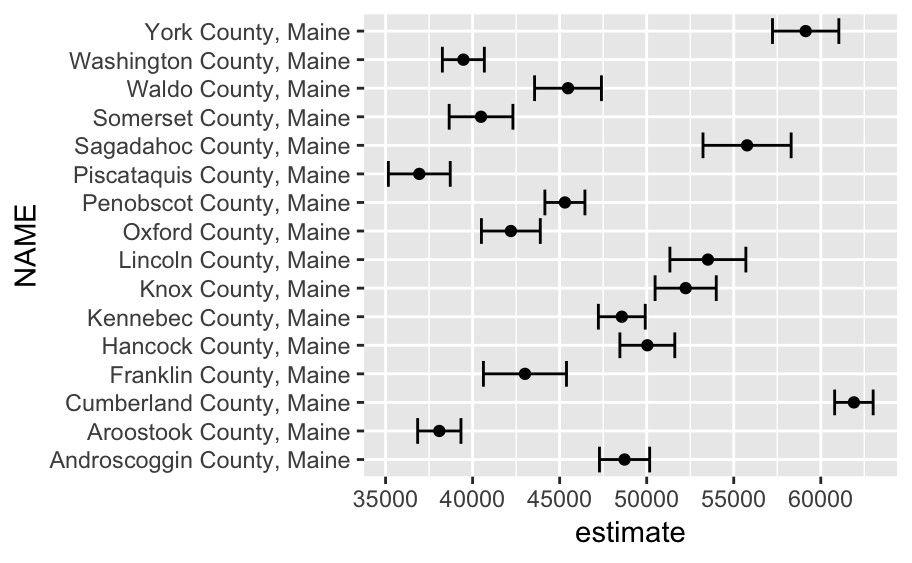

```r
# Request median household income data
maine_inc <- get_acs(geography = "county",
                     variables = c(hhincome = "B19013_001"),
                     state = "ME")
# Generate horizontal error bars with dots
ggplot(maine_inc, aes(x = estimate, y = NAME)) +
  geom_errorbarh(aes(xmin = estimate - moe, xmax = estimate + moe)) +
  geom_point()
```

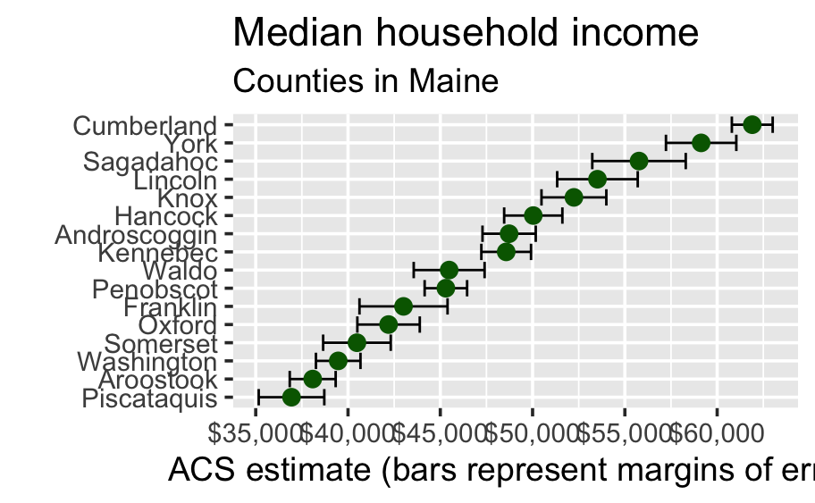

```r
# Remove unnecessary content from the county's name
maine_inc2 <- maine_inc %>%
  mutate(NAME = str_replace(NAME, " County, Maine", ""))

# Build a margin of error plot incorporating your modifications
ggplot(maine_inc2, aes(x = estimate, y = reorder(NAME, estimate))) +
  geom_errorbarh(aes(xmin = estimate - moe, xmax = estimate + moe)) +
  geom_point(size = 3, color = "darkgreen") +
  theme_grey(base_size = 14) +
  labs(title = "Median household income",
       subtitle = "Counties in Maine",
       x = "ACS estimate (bars represent margins of error)",
       y = "") +
  scale_x_continuous(labels = scales::dollar)
```

# Understanding Census geography and tigris basics

TIGER - Topologically integrated geologically encodind databse

`tigris` downloads line and shapes from Census Beuro and pulls them into R as Spatial objects.

Include geographic and tract regions. Also includes features such as roads and water features.

```r
library(tigris)
# Get a counties dataset for Colorado and plot it
co_counties <- counties(state = "CO")
head(co_counties)
```

```
An object of class "SpatialPolygonsDataFrame"
Slot "data":
```

|  | STATEFP | COUNTYFP | COUNTYNS | GEOID | NAME | NAMELSAD | LSAD | CLASSFP | MTFCC | CSAFP | CBSAFP | METDIVFP | FUNCSTAT | ALAND | AWATER | INTPTLAT | INTPTLON |
| --- | --- | --- | --- | --- | --- | --- | --- | --- | --- | --- | --- | --- | --- | --- | --- | --- | --- |
| 22 | 08 | 109 | 00198170 | 08109 | Saguache | Saguache County | 06 | H1 | G4020 | NA | NA | NA | A | 8206547711 | 4454510 | +38.0316514 | -106.2346662 |
| 106 | 08 | 115 | 00198173 | 08115 | Sedgwick | Sedgwick County | 06 | H1 | G4020 | NA | NA | NA | A | 1419419128 | 3530746 | +40.8715679 | -102.3553579 |
| 123 | 08 | 017 | 00198124 | 08017 | Cheyenne | Cheyenne County | 06 | H1 | G4020 | NA | NA | NA | A | 4605714032 | 8166134 | +38.8353865 | -102.6045852 |
| 162 | 08 | 027 | 00198129 | 08027 | Custer | Custer County | 06 | H1 | G4020 | NA | NA | NA | A | 1913031958 | 3364151 | +38.1019939 | -105.3735148 |
| 199 | 08 | 067 | 00198148 | 08067 | La Plata | La Plata County | 06 | H1 | G4020 | NA | 20420 | NA | A | 4376514359 | 25383359 | +37.2873673 | -107.8397178 |
| 227 | 08 | 111 | 00198171 | 08111 | San Juan | San Juan County | 06 | H1 | G4020 | NA | NA | NA | A | 1003660601 | 2035929 | +37.7810745 | -107.6702566 |

[output not shown]

[output cut: 3215 more lines]

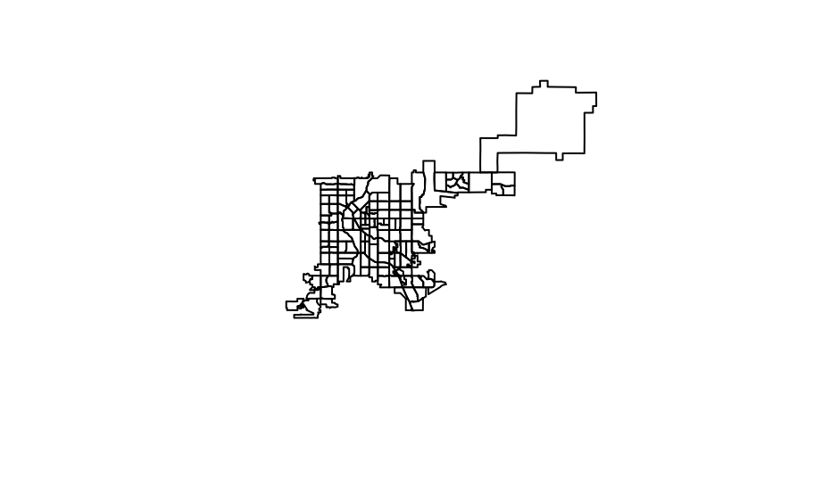

```r
# Get a Census tracts dataset for Denver County, Colorado and plot it
denver_tracts <- tracts(state = "CO", county = "Denver")
plot(denver_tracts)
```

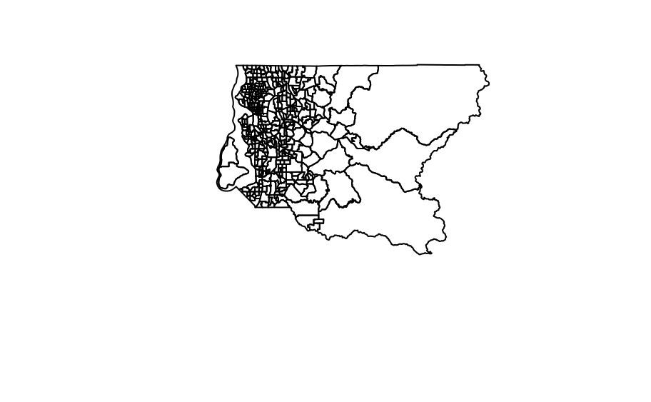

```r
king_tracts <- tracts(state="WA", county = "King")
plot(king_tracts)
```

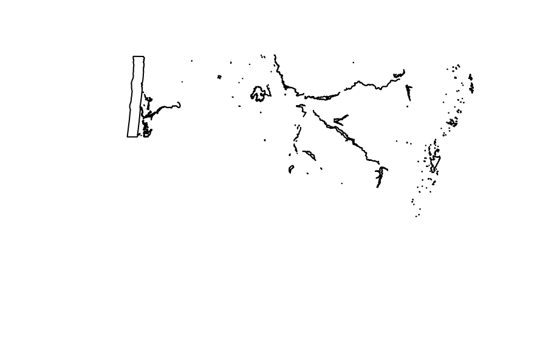

```r
# Plot area water features for Lane County, Oregon
lane_water <- area_water(state = "OR", county = "Lane")
plot(lane_water)
```

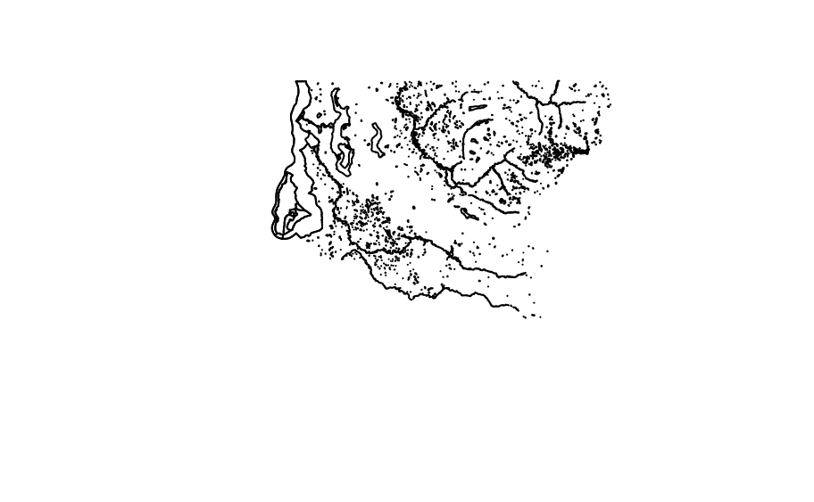

```r
king_water <- area_water(state = "WA", county = "King")
plot(king_water)
```

[figure not shown]

Looking at structure of the Spatial (sp) objects

```r
# Check the class of the data
class(co_counties)
```

```
[1] "SpatialPolygonsDataFrame"
attr(,"package")
[1] "sp"
```

```r
# Take a look at the information in the data slot
head(co_counties@data)
```

|  | STATEFP | COUNTYFP | COUNTYNS | GEOID | NAME | NAMELSAD | LSAD | CLASSFP | MTFCC | CSAFP | CBSAFP | METDIVFP | FUNCSTAT | ALAND | AWATER | INTPTLAT | INTPTLON |
| --- | --- | --- | --- | --- | --- | --- | --- | --- | --- | --- | --- | --- | --- | --- | --- | --- | --- |
| 22 | 08 | 109 | 00198170 | 08109 | Saguache | Saguache County | 06 | H1 | G4020 | NA | NA | NA | A | 8206547711 | 4454510 | +38.0316514 | -106.2346662 |
| 106 | 08 | 115 | 00198173 | 08115 | Sedgwick | Sedgwick County | 06 | H1 | G4020 | NA | NA | NA | A | 1419419128 | 3530746 | +40.8715679 | -102.3553579 |
| 123 | 08 | 017 | 00198124 | 08017 | Cheyenne | Cheyenne County | 06 | H1 | G4020 | NA | NA | NA | A | 4605714032 | 8166134 | +38.8353865 | -102.6045852 |
| 162 | 08 | 027 | 00198129 | 08027 | Custer | Custer County | 06 | H1 | G4020 | NA | NA | NA | A | 1913031958 | 3364151 | +38.1019939 | -105.3735148 |
| 199 | 08 | 067 | 00198148 | 08067 | La Plata | La Plata County | 06 | H1 | G4020 | NA | 20420 | NA | A | 4376514359 | 25383359 | +37.2873673 | -107.8397178 |
| 227 | 08 | 111 | 00198171 | 08111 | San Juan | San Juan County | 06 | H1 | G4020 | NA | NA | NA | A | 1003660601 | 2035929 | +37.7810745 | -107.6702566 |

```r
# Check the coordinate system of the data
co_counties@proj4string
```

```
CRS arguments:
 +proj=longlat +ellps=GRS80
+towgs84=0,0,0,0,0,0,0 +no_defs
```

Difference between cartogragphic and tigris boundaries

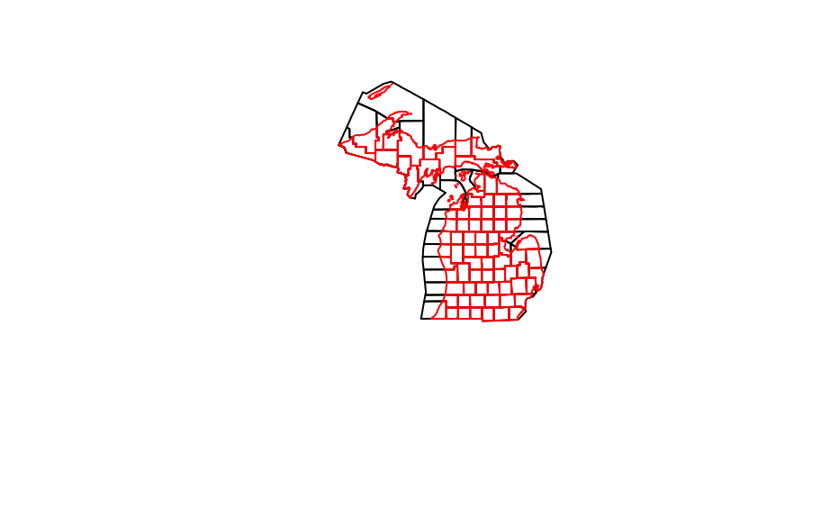

```r
# Get a counties dataset for Michigan
mi_tiger <- counties("MI")
# Get the equivalent cartographic boundary shapefile
mi_cb <- counties("MI", cb = TRUE)
# Overlay the two on a plot to make a comparison
plot(mi_tiger$geometry)
plot(mi_cb$geometry, add = TRUE, border = "red")
```

[figure not shown]

```r
# Get a historic Census tract shapefile from 1990 for Williamson County, Texas
williamson90 <- tracts(state = "TX", county = "Williamson",
                       cb = TRUE, year = 1990)
# Compare with a current dataset for 2016
williamson16 <- tracts(state = "TX", county = "Williamson",
                       cb = TRUE, year = "2016")
# Plot the geometry to compare the results
par(mfrow = c(1, 2))
plot(williamson90$geometry)
plot(williamson16$geometry)
```

```r
# Get Census tract boundaries for Oregon and Washington
or_tracts <- tracts("OR", cb = TRUE)
wa_tracts <- tracts("WA", cb = TRUE)
# Check the tigris attributes of each object
attr(or_tracts, "tigris")
```

```
[1] "tract"
```

```r
attr(wa_tracts, "tigris")
```

```
[1] "tract"
```

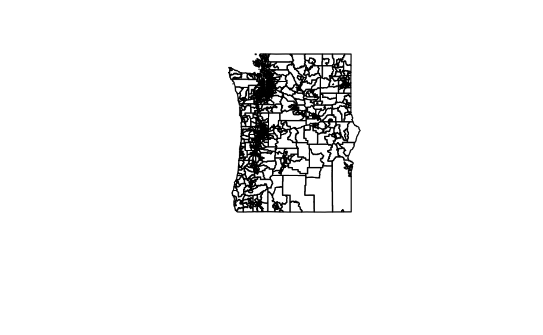

```r
# Combine the datasets then plot the result
or_wa_tracts <- rbind_tigris(or_tracts, wa_tracts)
plot(or_wa_tracts$geometry)
```

Tidy patterns can also be applied to combine multiple tigris (sf) objects together.

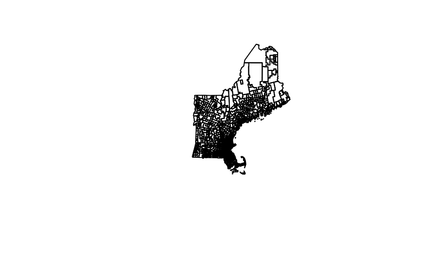

```r
# Generate a vector of state codes and assign to new_england
new_england <- c("ME", "NH", "VT", "MA")

# Iterate through the states and request tract data for state
ne_tracts <- map(new_england, function(x) {
  tracts(state = x, cb = TRUE)
}) %>%
  rbind_tigris()
plot(ne_tracts$geometry)
```

```r
tracts(state = "WA", house = "upper")
```

```
Error in load_tiger(url, tigris_type = "tract", ...) :
  unused argument (house = "upper")
```

```r
# Get boundaries for Texas and set the house parameter
tx_house <- state_legislative_districts(state = "TX", house = "lower", cb = TRUE)
# Merge data on legislators to their corresponding boundaries
tx_joined <- left_join(tx_house, tx_members, by = c("NAME" = "District"))
```

```
Error in check_join(x, y) : object 'tx_members' not found
```

[figure not shown]

```r
# Plot the legislative district boundaries
ggplot(tx_joined) +
  geom_sf()

# Set fill aesthetic to map areas represented by Republicans and Democrats
ggplot(tx_joined, aes(fill = Party)) +
  geom_sf()

# Set values so that Republican areas are red and Democratic areas are blue
ggplot(tx_joined, aes(fill = Party)) +
  geom_sf() +
  scale_fill_manual(values = c("R" = "red", "D" = "blue"))
```

```r
# Draw a ggplot without gridlines and with an informative title
ggplot(tx_joined, aes(fill = Party)) +
  geom_sf() +
  coord_sf(crs = 3083, datum = NA) +
  scale_fill_manual(values = c("R" = "red", "D" = "blue")) +
  theme_minimal(base_size = 16) +
  labs(title = "State House Districts in Texas")
```

[output not shown]

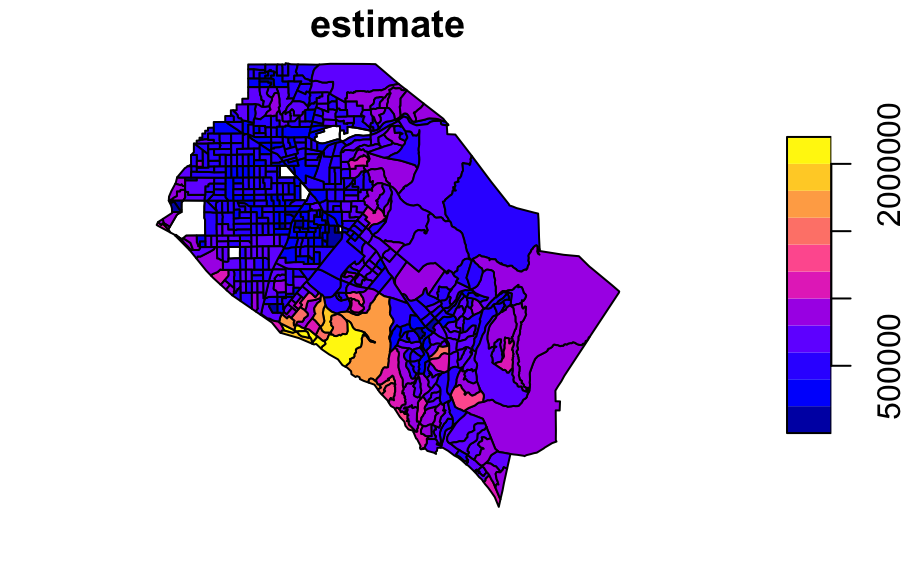

```r
library(tidycensus)
library(tidyverse)
library(sf)

# Get dataset with geometry set to TRUE
orange_value <- get_acs(geography = "tract", state = "CA",
                    county = "Orange",
                    variables = "B25077_001",
                    geometry = TRUE)
# Plot the estimate to view a map of the data
plot(orange_value["estimate"])
```

```r
# Get an income dataset for Idaho by school district
idaho_income <- get_acs(geography = "school district (unified)",
                        variables = "B19013_001",
                        state = "ID")

# Get a school district dataset for Idaho
idaho_school <- school_districts(state = "ID", type = "unified", class = "sf")

# Join the income dataset to the boundaries dataset
id_school_joined <- left_join(idaho_school, idaho_income, idaho_school, by = "GEOID")

plot(id_school_joined["estimate"])
```

[output not shown]

```r
# Get a dataset of median home values from the 1-year ACS
state_value <- get_acs(geography = "state",
                       variables = "B25077_001",
                       survey = "acs1",
                       geometry = TRUE,
                       shift_geo = TRUE)
```

```
The one-year ACS provides data for geographies with populations of 65,000 and greater.
Using feature geometry obtained from the albersusa package
Please note: Alaska and Hawaii are being shifted and are not to scale.
```

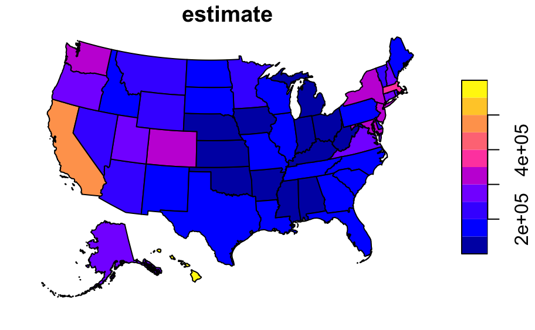

```r
# Plot the dataset to view the shifted geometry
plot(state_value["estimate"])
```

```r
# Set the color guide to FALSE and add a subtitle and caption to your map
ggplot(marin_value, aes(fill = estimate, color = estimate)) +
  geom_sf() +
  scale_fill_viridis_c(labels = scales::dollar) +
  scale_color_viridis_c(guide = FALSE) +
  theme_minimal() +
  coord_sf(crs = 26911, datum = NA) +
  labs(title = "Median owner-occupied housing value by Census tract",
       subtitle = "Marin County, California",
       caption = "Data source: 2012-2016 ACS.\nData acquired with the R tidycensus package.",
       fill = "ACS estimate")
```

[output not shown]

```r
# Generate point centers
centers <- st_centroid(state_value)

# Set size parameter and the size range
ggplot() +
  geom_sf(data = state_value, fill = "white") +
  geom_sf(data = centers, aes(size = estimate), shape = 21,
          fill = "lightblue", alpha = 0.7, show.legend = "point") +
  scale_size_continuous(range = c(1, 20))
```

[output not shown]

Other pacakges - censusapi - full census API access, very extensive - ipumsr - historical data - cancensus - Canadian census

Other Recommendations - Working with data in the tidyverse - data visualizeation with ggplot2 - interactive maps with leaflet in R